# Logbook Janine Postmus

Janine Postmus

2024-09-10

### Inleiding genomics

In dit logboek zal ik bijhouden wat ik voor het project Genomics & Transcriptomics, leerjaar 2 kwartaal 1, allemaal uitvoer. Hierbij onderbouw ik mijn keuzes met waarom ik iets doe hoe ik dat heb gedaan. Ik maak gebruik van de wat, hoe en waarom methode. Wat heb ik gedaan? Hoe heb ik dit gedaan en waarom heb ik dit gedaan? Ook zal ik hier resultaten van tonen.

##09-09-2024  
Nadat we de uitleg hebben gekregen hebben we groepen gevormd. Mijn groep is samen met Ramon, Jasper en Iris. We hebben vervolgens een begin gemaakt met het zoeken naar een wetenschappelijk artikel. Dit hebben we gedaan via de volgende link: Wetenschappelijke artikelen We hebben afgesproken dat we allemaal 1 artikel uitzoeken en uiteindelijk op basis van Marcel zijn oordeel een definieve keus maken. Marcel controleert de artikelen of deze voldoende informatie bevatten zodat het voor ons te repliceren is. De keuzes waren:  
- MLL-leukemie-inductie door t(9;11)-chromosomale translocatie in menselijke hematopoietische stamcellen met behulp van genoombewerking. Gekozen door Iris.  
- De behandeling van Entinostat op blaaskanker in de muis. Gekozen door Jasper.  
- IGF2BP1 geïnduceert neuroblastoom dat oncogenexpressie bevordert. Gekozen door Ramon.  
- Het DNA-methylatielandschap van de progressie van de ziekte van glioblastoom. Gekozen door Janine.

##10-09-2024  
De experimenten van Janine en Iris zijn afgekeurd wegens ontbrekende of onvoldoende data. Vervolgens hebben we als groep gekozen voor Jasper zijn artikel.  
We hebben gekozen voor een onderzoek met de behandeling van Entinostat op blaaskanker. Het onderwerp interesseert mij heel erg omdat ik kanker een interessant onderwerp vind. De entinostat werkt heel erg op genexpressie en het immuunsysteem. Ik vind genexpressie erg interessant omdat dit heel veel bepaald in ons lichaam.  
Onze onderzoeksvraag is: Hoe kunnen de mutaties die we vinden blaaskanker veroorzaken?

##11-09-2024  
We hebben een taakverdeling gemaakt voor het plan van aanpak.  
Ik ga het onderzoekoverzicht, de achtergrond ervan en een globale theoretische achtergrond presenteren tijdens de presentatie.  
Iris gaat de Gantt chart maken.  
Jasper gaat de workflow maken.  
Ramon zet het plan van aanpak en de presentatie in elkaar. Verder hadden we vandaag statistiek les dus geen tijd meer gehad voor dit project.

##12-09-2024  
Ik heb het artikel doorgelezen en de kernwoorden eruit gehaald zodat ik hierop verder kon bouwen aan de theoretische achtergrond. De volgende kernwoorden heb ik gebruikt:  
- Immuuncheckpointremmers (ICI’s)  
- Entinostat  
- Histondeacetylase remmers (HDAC remmers)  
- Immuunreactie op tumor-neo antigenen

Ik heb vanuit het artikel de kopjes Abstract en Introduction hiervoor gebruikt. Hier staat dusdanig veel informatie in over het onderzoek dat hier voor het plan van aanpak voldoende uit te halen valt. Ik heb gebruik gemaakt van online resourches en voor het vertalen van het artikel heb ik gebruik gemaakt van copilot. Voor de bronnen en de verwerking van de kernwoorden kan gekeken worden in ons Plan van Aanpak. Dit is te vinden in onze [Github](https://github.com/RamonReilman/GenomicsTranscriptomics) onder Plan van aanpak.

##13-09-2024  
Ik heb de theorie aangevuld met de laatste dingen. In de pva staat die onder alinea ‘Entinostat en zijn werking’.  
Smiddags is er een les gevolgd over hoe we data kunnen downloaden op de schoolserver. Hier heeft Ramon meegedaan met de les en het voor onze data uitgevoerd. Ik heb voor mijzelf aantekeningen gemaakt.

##15-09-2024  
Naar aanleiding van feedback vanuit de groep heb ik een deel van de theorie aangepast en aangevuld. Er klopte iets niet over de projectopzet, ik heb dit gecorrigeerd en vervolgens gemeld aan de groep zodat de presentatie afgemaakt kon worden.  
De presentatie is afgemaakt door Ramon. Omdat ik met een gebroken enkel in huis vast zit, gaat Ramon mijn deel van de presentatie doen en gaan we maandag afspraken maken over de verdere uitvoering van het project.

##17-09-2024  
Ik heb de tool snpEff gekregen/gekozen als onderdeel van het project. Omdat ik de komende weken minder op school aanwezig kan zijn hebben we deze tool aan mij toebesteed omdat deze tool pas redelijk aan het einde van het proces nodig is. Hierdoor krijg ik meer tijd om processen en dingen te onderzoeken voordat we de tool daadwerkelijk nodig zijn.

De verdeling van de tools is alsvolgt:  
- BWA - Mapping –> Jasper  
- Picard - Duplicates –> Iris  
- Strelka - Variant calling –> Ramon  
- SnpEff - Variant annotation –> Janine

De volgende tools hebben we allemaal zelf geleerd en uitgevoerd:  
- Seqkit -> Making testdata - Fastqc -> Making data quality rapports  
- Multiqc -> Making data quality rapports from multiple fastqc rapports  
- Trimmomatic - Trimming data to enhance data quality

Om te leren hoe we moeten omgaan met de data en testdata heb ik met behulp van de tool seqkit testdata gemaakt voor ons project. Ik heb de testdata gemaakt op basis van onze echte data.  
Ik heb dit eerst uitgevoerd op 1 bestand om te leren hoe het werkt. Omdat onze dataset uit heel veel bestanden bestaat, is het noodzakelijk dat ik leer hoe ik het kan uitvoeren op alle bestanden. Ik weet dat ik de find functie moet gebruiken icm de tools fastqc en parallel, hoe ik het moet gebruiken weet ik nog niet. Verder hebben we afgesproken dat ik alle stappen van het preprocessing traject, dus de fastqc, multiqc en trimmomatic zelf ga uitvoeren met testdata om goed te begrijpen wat we doen.

Gebruikte commandline voor seqkit om testdata te maken van 1 fastq file:

```bash
Seqkit head -n 10000 /.x.fastq -o /.x.fastq
```

Hierin is /. x.fastq een inputfile, hierbij moet het absolute pad naar de map gebruikt worden.  
-o /.x.fastq is het outputfile, ook hier moet het absolute pad naar de map gebruikt worden.

Vervolgens moet er een fastqc rapport gemaakt worden van alle files in de map. Fastqc is een tool die ervoor zorgt dat de data overzichtelijk in een quality rapport komt te staan. Hier worden de volgende onderdelen op kwaliteit beoordeeld:  
- Basic Statistics  
- Per sequence counts  
- Per base sequence quality  
- Per sequence quality scores  
- Per base sequence content  
- Per sequence GC content  
- Per base N content  
- Sequence Duplication Levels  
- Overrepresented Sequences  
- Adapter Content

Fastqc uitvoeren op meerdere bestanden in 1 keer.

```bash
find /students/2024-2025/Thema05/BlaasKanker/fastq -name "*.fastq" |parallel fastqc -o /students/2024-2025/Thema05/BlaasKanker/oefenengroep/testdataJanine/MultiqcJanine/{}
```

Find wordt gebruikt om de map met files te vinden en hiervan een lijst te maken. Path to file staat voor het volledige pad naar het bestand. Het invoer bestand was in dit geval onze map met testdata. De output is in een persoonlijke map gekomen waarin we alle 4 zelf kunnen testen. De {} wordt gebruikt om aan te geven dat hier de uitvoerbestanden inkomen.

##18-09-2024  
Omdat er met veel data gewerkt wordt heb je dus veel bestanden waarvan een fastqc rapport gemaakt wordt. Omdat het heel moeilijk, zo niet onmogelijk, is om al deze bestanden met het oog los van elkaar te beoordelen gebruiken we hiervoor de tool multiqc. Ik heb uitgezocht hoe ik het multiqc rapport moet maken. Via verschillende bronnen en forums op internet heb ik de goede commandline geproduceerd en vervolgens uitgevoerd.

```bash
find find /students/2024-2025/Thema05/BlaasKanker/fastq -name "*.fastq" |parallel multiqc -o /students/2024-2025/Thema05/BlaasKanker/oefenengroep/testdataJanine/MultiqcJanine/{}
```

##20-09-2024  
Om beter te begrijpen wat al deze kwaliteitscontroles, van de fastqc en multiqc, nu eigenlijk zeggen heb ik hier een verslag van gemaakt. Dit verslag staat in onze teams groep. “2.1.2 Genomics & transcriptomics Ramon Reijlman, Janine Postmus, Jasper Jonker en Iris Ineke” met de titel “Verslag_multiqc_rapport.docx”.

Ik vind het belangrijk om het op deze manier te hebben gedaan omdat ik op deze manier sneller inzicht kan creeëren voor mijzelf hoe zo’n rapport werkt en welke onderdelen het belangrijkste zijn. Ik zal hier de conclusie neerzetten die ook in het verslag staat. Dit is op basis van de getrimde data welke we op dit moment hebben.

Conclusie:  
Onze data is op de meeste vlakken goed/zeer goed. Het enige wat opvalt is dat er een relatief hoog duplicatieniveau is. Dit kan meerdere oorzaken hebben. De meest waarschijnlijke reden in deze data is dat er sprake is van PCR overamplificatie of van zeer expressieve genen in de RNA-sequentie data. Omdat er gebruik is gemaakt van Entinostat wat de expressie van genen stimuleert is dit een optie. Omdat we de data niet zelf hebben geproduceerd, kunnen we hier nooit helemaal met zekerheid iets over zeggen.

##22-09-2024  
Omdat het trimmen van de data nog niet goed is gegaan hebben wij dit allemaal opnieuw uitgevoerd en uitgezocht wat de goede commandline is. Ik heb dit gedaan door eerst te kijken naar wat trimmomatic is voor programma en de documentatie goed door te nemen. Ik heb hiervoor de officiële documentatie gelezen van trimmomatic via: [documentatie trimmomatic](http://www.usadellab.org/cms/uploads/supplementary/Trimmomatic/TrimmomaticManual_V0.32.pdf)  
Verder heb ik deze video op youtube gekeken:[bioinformatics trimmomatic](https://www.youtube.com/watch?v=Op3W5TEej3k)

Ik heb in de documentatie vooral gekeken naar de opties die je met trimmomatic kan meegeven en welke gunstig zouden zijn voor onze data. Ik denk dat de opties ILUMACLIP, MINLEN, LEADING en TRAILING voor ons project gunstig zijn.  
- ILUMACLIP zorgt ervoor dat als er adapters zijn toegevoegd aan de data dat deze gevonden en verwijderd worden. Adaptersequenties kunnen de kwaliteit van de data beïnvloeden en ervoor zorgen dat er foutieve resultaten in de analyse zitten. Hierdoor krijg je betrouwbaardere informatie.  
- MINLEN is een optie waarbij je kan aangeven dat er een het aantal reads, dat onder de gespecificeerde minimumlengte zit, verwijderd wordt.  
- LEADING is een optie welke de basen aan de voorkant van de read, welke meestal een slechte kwaliteit hebben, verwijderd wordt.  
- TRAILING is een optie welke de basen aan de achterkant van de read, welke meestal een slechte kwaliteit hebben, verwijderd wordt.

##23-09-2024  
Verder gegaan met trimmomatic, het zoeken naar de goede instellingen zodat het fastq rapport zoveel mogelijk groen kleurt. Dit is belangrijk om zo te kunnen kijken of de data nog verder geperfectioneerd kan worden. Hoe meer groen de dataset is hoe beter deze gebruikt kan worden voor de volgende stap in het proces, de mapping.

Ik heb het command voor trimmomatic hier neergezet om het zo makkelijker aan te kunnen passen om makkelijker met de settings te kunnen experimenteren, dit is ook het uiteindelijke command geworden.

```bash
cat /students/2024-2025/Thema05/BlaasKanker/SRR_Acc_List.txt | \
    parallel 'TrimmomaticPE -threads 10' \
            '/students/2024-2025/Thema05/BlaasKanker/outputs/fastq/{}_1.fastq' \
            '/students/2024-2025/Thema05/BlaasKanker/outputs/fastq/{}_2.fastq' \
            '/students/2024-2025/Thema05/BlaasKanker/oefenengroep/testdataJanine/trimdata/paird/{}paired_1.fastq' \
            '/students/2024-2025/Thema05/BlaasKanker/oefenengroep/testdataJanine/trimdata/unpaird/{}unpaired_1.fastq' \
            '/students/2024-2025/Thema05/BlaasKanker/oefenengroep/testdataJanine/trimdata/paird/{}paired_2.fastq' \
            '/students/2024-2025/Thema05/BlaasKanker/oefenengroep/testdataJanine/trimdata/unpaird/{}unpaired_2.fastq' \
            'LEADING:3' \
            'TRAILING:3' \
            'SLIDINGWINDOW:4:20' \
            'MINLEN:40'
```

##24-09-2024  
Het trimmen van de data heb ik afgemaakt, het zoeken naar de goede settings om hier vervolgens fastqc op los te laten en een multiqc rapport maken zodat ik dit kan vergelijken met het multiqc rapport voor het trimmen van de data. Wordt de data beter? Wordt het slechter? Wat zegt dat over de data? Ik heb eerst de settings gebruikt zoals gelogd op 23-09-2024.

Na het trimmen van de data komen er 4 files als output namelijk: - R1_paired - R1_unpaired - R2_paired - R2_unpaired

De paired bestanden worden gebruikt voor de verdere bewerking omdat paired data beide kanten van de read gebruikt. Dit is gunstig omdat je op deze manier zoveel mogelijk data meeneemt in je beoordeling. Bij unpaired data wordt maar 1 kant van de read gebruikt waardoor er veel verlies is van data en dus mogelijk de mutaties die je nodig bent.

Vervolgens heb ik op de paired fastq files fastqc losgelaten en hier een multiqc van gemaakt.

Eerst fastqc maken van de paired data

```bash
fastqc /students/2024-2025/Thema05/BlaasKanker/oefenengroep/testdataJanine/trimdata/paird/* \
    -o /students/2024-2025/Thema05/BlaasKanker/oefenengroep/testdataJanine/trimdata/trimfastqc -t 12
```

Daarna multiqc maken van de fastqc’s van de paired data

```bash
multiqc /students/2024-2025/Thema05/BlaasKanker/oefenengroep/testdataJanine/trimdata/trimfastqc/* \
    -o /students/2024-2025/Thema05/BlaasKanker/oefenengroep/testdataJanine/trimdata/multiqctrim/
```

Door onderstaande settings te gebruiken heb ik een multiqc rapport gecreeërd, tot onze grote verbazing blijkt deze leeg te zijn. Voor vandaag heb ik het opgegeven om er nog verder mee bezig te gaan. Ronald is op de hoogte gesteld en gaat voor ons kijken of hij het kan oplossen. Uiteindelijk blijkt het probleem alleen bij mij voor te komen, de reden hiervoor is onbekend en in overleg met Ronald laten we het hierbij voor dit project.

| Run ID | LEADING | TRAILING | SLIDING WINDOW | MINLEN | AVGQUAL | HEADCROP | CROP | ILLUMINACLIP |
| --- | --- | --- | --- | --- | --- | --- | --- | --- |
| Data van | 3 | 3 | 4:20 | 40 | NONE | NONE | NONE | NONE |
| project |  |  |  |  |  |  |  |  |

Jasper is begonnen met de tool BWA voor de mapping van onze data. Kijk voor informatie hierover in het logboek van Jasper. Te vinden op onze github onder logbooks, JasperJonkerLogbooks: [github](https://github.com/RamonReilman/GenomicsTranscriptomics)

##26-09-2024  
Ramon heeft de volgende trimmomatic settings gebruikt. Dit zijn de settings die uiteindelijk gebruikt voor de mapping:

| Run ID | LEADING | TRAILING | SLIDING WINDOW | MINLEN | AVGQUAL | HEADCROP | CROP | ILLUMINACLIP |
| --- | --- | --- | --- | --- | --- | --- | --- | --- |
| Data van | 34 | 34 | NONE | 40 | NONE | NONE | NONE | NONE |
| project |  |  |  |  |  |  |  |  |

Ik heb vandaag besteed aan mij inlezen over de tool SnpEff (versie 5.2C), ik wil begrijpen hoe deze tool werkt, waarom we hem gebruiken en hoe we deze gaan inzetten op ons project. Ik heb de tool alvast op de schoolserver in ons project gedownload. Ik ga morgen verder met uitzoeken hoe de tool werkt en meer over de tool leren.

##27-09-2024  
Ik ben begonnen met het nalezen en aanvullen van mijn logboek. Daarna ben ik verder gegaan met het leren van SnpEff. De tool is correct gedownload op de server en werkt. Door Ramon is er een test data set gemaakt met output van BWA mapping, die ik kan gebruiken om een goede commandline op te stellen voor deze tool. Dit is handig om dit vooraf te doen zodat ik, wanneer we eraan toe zijn met de echte data, alleen de data hoef te veranderen waardoor het gehele groepsproces sneller gaat. Ik heb dit filmpje gekeken: [filmpje snpeff](https://www.youtube.com/watch?v=-rmreyRAbkE&t=544s) en de officiële documentatie gelezen: [snpEff documentatie](https://pcingola.github.io/SnpEff/snpeff/introduction/)

Iris heeft picard op de echte data uitgevoerd om het hoge aantal duplicaten te verwijderen. Kijk hiervoor in [Logboek Iris](https://github.com/RamonReilman/GenomicsTranscriptomics)

##29-09-2024  
Aan het testen gegaan met snpEff op een testdata set. Deze testdata set is door Ramon gemaakt en te vinden in: /students/2024-2025/Thema05/BlaasKanker/testingtools/test_variant_calling

Test command 1:

```bash
java -Xmx8g -jar /students/2024-2025/Thema05/BlaasKanker/tools/snpeff/snpEff/snpEff.jar eff \
mm39 /students/2024-2025/Thema05/BlaasKanker/testingtools/test_variant_calling/SRR14870694_variants.vcf \
> /students/2024-2025/Thema05/BlaasKanker/testingtools/test_variant_calling/test_output_variants.vcf
```

Bij het downloaden van de referencegenome is de volgende foutmelding gekomen:  
FATAL ERROR: Failed to download database from [https://snpeff.blob.core.windows.net/databases/v5_2/snpEff_v5_2_mm39.zip, https://snpeff.blob.core.windows.net/databases/v5_0/snpEff_v5_0_mm39.zip, https://snpeff.blob.core.windows.net/databases/v5_1/snpEff_v5_1_mm39.zip]

Oplossing:  
Door te zoeken op internet ben ik een github forum tegengekomen die een mogelijke oplossing bied. Ik ga de volgende stappen uitvoeren vanaf deze [github](https://github.com/pcingola/SnpEff/issues/536)  
De stappen beschreven door gebruiker ‘lukedow’:

**Problemsolving**  
I had the same issue with mm39, but was eventually able to build the db manually. I tried a few of the options in the snpEff documentation, but the one that ultimately worked was the .gtf approach.

Most of what you need to know is in the documentation, but not always super clear. Here were the key points for me:

Make sure you retrieve all of the required FASTA and GTF (and/or GFF) files from the same genome build, e.g. from UCSC (https://useast.ensembl.org/Mus_musculus/Info/Index). Unzip them into a specific directory (snpEff/data/mm39/) so the script can find them, and rename the files:  
Mus_musculus.GRCm39.dna.primary_assembly.fa.gz: sequences.fa Mus_musculus.GRCm39.cds.all.fa.gz: cds.fa Mus_musculus.GRCm39.pep.all.fa.gz: protein.fa Mus_musculus.GRCm39.112.gtf.gz: genes.gtf

Modify the snpEff.config file to include the line: mm39.genome : Mouse

Build the database: java -Xmx4g -jar snpEff.jar build -gtf22 -v mm39

This should create and save the .bin files required for annotation into /snpEff/data/mm39/ Should be good to go!

##Vervolg logboek 29-09-2024  
Ik heb alle stappen exact zoals hierboven beschreven uitgevoerd. Daarna heb ik opnieuw onderstaand command uitgevoerd.

```bash
java -Xmx8g -jar /students/2024-2025/Thema05/BlaasKanker/tools/snpeff/snpEff/snpEff.jar eff \
mm39 /students/2024-2025/Thema05/BlaasKanker/testingtools/test_variant_calling/SRR14870694_variants.vcf \
> /students/2024-2025/Thema05/BlaasKanker/testingtools/test_variant_calling/test_output_variants.vcf
```

Het command werkt er is een output gecreeërd van een enkel file. Ik ga nu het command zo aanpassen dat hij de hele map aan vcf files in 1 keer meeneemt.

```bash
ls /students/2024-2025/Thema05/BlaasKanker/testingtools/test_variant_calling/*.vcf | parallel -j 4 \
"java -Xmx8g -jar /students/2024-2025/Thema05/BlaasKanker/tools/snpeff/snpEff/snpEff.jar eff mm39 > /students/2024-2025/Thema05/BlaasKanker/testingtools/test_variant_calling/test_output_variants/{/.}.vcf"
```

- Xmx8g -> stelt de maximale hoeveelheid geheugen in die Java mag gebruiken.
- eff -> voor het annoteren van de varianten
- verbose (-v) -> Hiermee wordt een gedetailleerd logbestand gemaakt die handig kan zijn voor foutopsporing

Het command ziet er dan alsvolgt uit:

```bash
ls /students/2024-2025/Thema05/BlaasKanker/testingtools/test_variant_calling/*.vcf | parallel -j 4 \
"java -Xmx8g -jar /students/2024-2025/Thema05/BlaasKanker/tools/snpeff/snpEff/snpEff.jar ann -v -stats /students/2024-2025/Thema05/BlaasKanker/testingtools/test_variant_calling/test_output_variants/ex1.html mm39 > /students/2024-2025/Thema05/BlaasKanker/testingtools/test_variant_calling/test_output_variants/{/.}.vcf"
```

Bovenstaand command werkt, echter is de output leeg van de testdata leeg. De reden hiervoor is op dit moment onbekend.

##01-10-2024  
We hebben besloten om tussen de stappen variant calling en variant annotation een filter stap toe te voegen. Dit doen we met de tool VcfFilter. Deze tool filtert de data dusdanig dat alleen de meest relevante data behouden wordt. Dit scheelt tijd omdat de hoeveelheid data aanzienlijk vermindert door de filterstap. Voor de uitvoering kan er gekeken worden in het logboek van Ramon Reilman. –>

```bash
ls /students/2024-2025/Thema05/BlaasKanker/outputs/variant_calling_unfiltered/*.vcf | parallel -j 8 \
"java -Xmx8g -jar /students/2024-2025/Thema05/BlaasKanker/tools/snpeff/snpEff/snpEff.jar ann -v -stats /students/2024-2025/Thema05/BlaasKanker/outputs/variant_annotation_unfiltered/stats.html mm39 > /students/2024-2025/Thema05/BlaasKanker/outputs/variant_annotation_unfiltered/{/.}.vcf"
```

Na het uitvoeren van bovenstaand command krijg ik de volgende foutmelding: WARNING!: Mitochondrion chromosome ‘MT’ does not have a mitochondrion codon table (codon table = ‘Standard’). You should update the config file. Ik probeer uit te zoeken waar ik de tabel kan vinden om deze in het configuration file toe te voegen.

Omdat ik niet precies weet waar het misgaat heb ik besloten de database rondom mm39 opnieuw te bouwen. Hiervoor volg ik deze instructie [github instructie] (https://pcingola.github.io/SnpEff/snpeff/build_db/)  
Ik heb van deze link op het [ncbi](https://www.ncbi.nlm.nih.gov/datasets/genome/GCF_000001635.27/) de fasta sequence, gft en gff file gedownload. Deze heb ik in de volgende map gezet: /students/2024-2025/Thema05/BlaasKanker/tools/snpeff/snpEff/data/mm39.

Na het opnieuw bouwen van de database en uitvoeren van de tool op onze data krijg ik nog steeds de foutmelding: Mitochondrion chromosome ‘MT’ does not have a mitochondrion codon table (codon table = ‘Standard’).

Ik heb voor nu besloten om hulp te vragen bij de docenten, ook Ramon kijkt nog even mee.

Ramon heeft Lofreq uitgevoerd voor de variant calling. Te vinden op onze [github](https://github.com/RamonReilman/GenomicsTranscriptomics) onder logbooks, RamonReilmanLogbooks:

##2-10-2024  
Ramon heeft laten zien dat hij door middel van nog 2 andere tools mijn tool snpEff bijna werkend heeft gekregen. Kijk voor de stappen die hij heeft ondernomen in zijn logboek: Te vinden op onze [github](https://github.com/RamonReilman/GenomicsTranscriptomics) onder logbooks, RamonReilmanLogbooks:

##3-10-2024  
Ik heb afgelopen week feedback gekregen op mijn logboek van Ronald. Hierbij is gebleken dat ik alles veel duidelijker en uitgebreider moet verwoorden. Daarom neem ik hier vandaag de tijd voor om het hele logboek van vooraan tot en met nu volledig aan te vullen. Hierbij ga ik de hoe, wat en waarom toepassen om op deze manier zoveel mogelijk tijdsverantwoording te vangen.

Ik ga onderzoeken of we de output vcf bestanden die uit de variant annotation komen ook kunnen filteren op impact van mutaties. Hiermee zouden we het lezen en interpreteren van de mutaties namelijk veel makkelijker maken. Ik ga kijken of hier tools voor zijn en en welke dat zijn.

Er zijn in principe 2 tools die dit kunnen doen en dit zijn VEP (Variant effect predictor) en SnpSift. Omdat SnpSift samenwerkt met SnpEff is het in dit geval de meest gunstige tool om te gebruiken. SnpSift is een toolbox met heel veel verschillende opties. Ik ga onderzoeken welke opties we het beste kunnen gebruiken om een zo gunstig mogelijke uitkomst te genereren. Wanneer de meest optimale uitkomst hebben kunnen we hier makkelijker plotjes van maken voor ons wetenschappelijke artikel.

##04-10-2024  
Na overleg met de groep hebben we besloten om SnpSift te gaan gebruiken om de impact van de genen en de soort puntmutatie eruit te filteren. SnpSift heeft hier een filter functie voor met de opties IMPACT en FUNCLASS.  
In de IMPACT optie kunnen de volgende waarden meegegeven worden:  
- High  
- Moderate  
- Low  
- Modifier

In de FUNCLASS optie kunnen de volgende waarden meegegeven worden:  
- None  
- Silent  
- Missense  
- Nonsense

De impact wat de varianten van genen hebben kan betekenen dat het verloop van de ziekte, hoe erg het zich uit bijvoorbeeld, daarmee aan te duiden is.

Wanneer we het over de modifier optie hebben, dan gaat het om modifier genes. Deze genen spelen een rol in de variabiliteit van de fenotypische expressie van de ziekte. In het geval van blaaskanker bij muizen, kunnen modifier-genen de groei, progressie en respons op behandeling van tumoren beïnvloeden. Deze genen kunnen varianten bevatten die de expressie van andere genen moduleren, wat leidt tot verschillen in tumorontwikkeling en -gedrag tussen individuen. Dit is dus een belangrijke optie om mee te geven, deze genen willen we wel meenemen in het onderzoek.

Low impact genen (optie low impact) zijn meestal varianten die geen tot weinig impact hebben op de ziekte en het verloop hiervan. In [dit artikel](https://genomebiology.biomedcentral.com/articles/10.1186/s13059-017-1212-4#Sec1) is wel te lezen dat er nog veel onderzoek is te doen naar low impact genen omdat het wel de fenotypische expressie kan beïnvloeden. Echter is er nog zeer weinig bekend over wat nu de precieze impact is van low impact genes. Voor ons onderzoek lijkt het niet relevant te zijn om deze genen mee te nemen dus dat gaan we niet doen.

High impact genes hebben zoals de naam al doet vermoeden een zeer grote impact op de ziekte en het verloop hiervan. Deze genen kunnen aanzienlijke veranderingen veroorzaken in eiwitten of de regulatie van de genen. Door deze veranderingen hebben ze een zeer groot fenotypisch effect hebben op de expressie en verloop van de ziekte. Deze optie wordt dus meegenomen in ons onderzoek.

Tijdens het onderzoeken naar al deze achtergrondinformatie hebben we besloten de tool toch niet te gaan gebruiken. Daarom ga ik geen extra tijd besteden aan meer theoretische achtergrond zoeken.

##11-10-2024  
Ramon is vandaag nog met de plotjes bezig om te kijken of dit werkend te krijgen is. Jasper, Iris en ik hebben de logboeken tegen elkaar aan gelegd en alle belangrijke stappen overgenomen van elkaar. Ook heb ik nog het logboek aangevuld met informatie.

##16-10-2024  
Ik heb de lollipop plot van [Ramon zijn logboek](https://github.com/RamonReilman/GenomicsTranscriptomics/tree/main/logbooks) overgenomen.

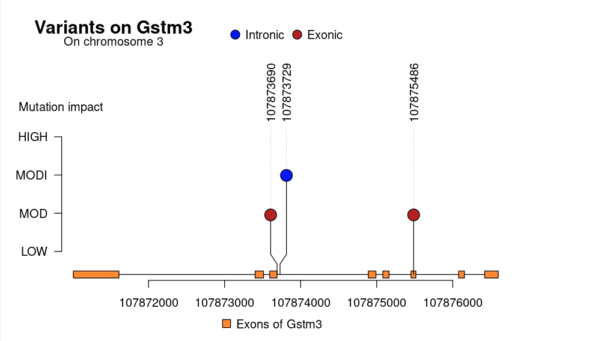